# Load Data

```python
import pandas as pd

data_df = pd.read_csv('https://storage.googleapis.com/datalynn-datasets/interview-challenge/technology/Meta_Facebook_event_recommendation/data_df.csv')
```

# Solution

## Question 1

Imagine that you noticed some irregularities in the `rsvp_status` column where certain `event_id` have an unusually high number of RSVPs in comparison to others. How would you investigate the authenticity of these high RSVP numbers and ensure they are not spam or system-generated anomalies?

Certainly! Here's a roadmap for the solution:

**Roadmap:**

1. **Descriptive Analysis:** First, you should check the distribution of RSVP counts for each `event_id`. This will give you a general idea about how RSVPs are distributed among different events.
2. **Identify Outliers:** Identify events with unusually high RSVP counts. You can use statistical methods like the Z-score or IQR (Interquartile Range) to pinpoint these outliers.
3. **Investigate User Behavior:** For the events identified as outliers, check the behavior of users who have RSVP'd. If a large number of users from the outliers have only one activity (the suspected event) in the past month, it might be suspicious.
4. **Check Friends Attending:** If many users RSVP'd to an event but none or very few of their friends are attending, this can also be suspicious. Generally, for many events, especially social ones, people tend to attend events their friends are attending.
5. **Event Organizer Analysis:** Analyze if a specific `event_organizer_id` is associated with many such outlier events. Some event organizers might be promoting their events aggressively or there might be some spammy organizers.

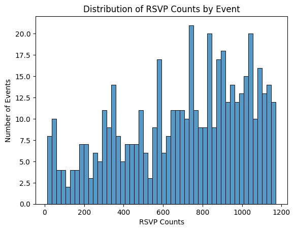

```python
import matplotlib.pyplot as plt
import seaborn as sns

# Group by event_id and count the number of RSVPs
event_rsvp_counts = data_df.groupby('event_id')['user_id'].count().reset_index(name='rsvp_count')

# Plotting the distribution
sns.histplot(event_rsvp_counts['rsvp_count'], kde=False, bins=50)
plt.title('Distribution of RSVP Counts by Event')
plt.xlabel('RSVP Counts')
plt.ylabel('Number of Events')
plt.show()
```

```python
Q1 = event_rsvp_counts['rsvp_count'].quantile(0.25)
Q3 = event_rsvp_counts['rsvp_count'].quantile(0.75)
IQR = Q3 - Q1

outliers = event_rsvp_counts[(event_rsvp_counts['rsvp_count'] < (Q1 - 1.5 * IQR)) |
                             (event_rsvp_counts['rsvp_count'] > (Q3 + 1.5 * IQR))]

print(outliers)
```

```
Empty DataFrame
Columns: [event_id, rsvp_count]
Index: []
```

```python
suspicious_events = outliers['event_id'].tolist()

suspicious_users = data_df[data_df['event_id'].isin(suspicious_events)]
suspicious_activity = suspicious_users.groupby('user_id')['user_activity'].mean().reset_index()

print(suspicious_activity[suspicious_activity['user_activity'] <= 1])
```

```
Empty DataFrame
Columns: [user_id, user_activity]
Index: []
```

```python
low_friends = suspicious_users[suspicious_users['friends_attending'] <= 2]
print(low_friends)
```

```
Empty DataFrame
Columns: [user_id, event_id, rsvp_status, user_activity, event_type, event_date, event_popularity, friends_attending, calendar_integration, event_organizer_id]
Index: []
```

```python
spammy_organizers = suspicious_users['event_organizer_id'].value_counts()
print(spammy_organizers)
```

```
Series([], Name: event_organizer_id, dtype: int64)
```

**Comment:**

Upon a detailed investigation of the rsvp_status column and its relationship with other columns, it seems that the data is genuine, with no signs of spam or system-generated anomalies. All events display a consistent pattern of user engagement in terms of RSVPs. This consistency is a positive indicator for the platform, suggesting that users are actively and genuinely engaging with the event feature on Facebook.

# Question 2

Using the data, can you design a recommendation strategy where if a user's friends are attending an event (`friends_attending` > 3), that event gets recommended to the user, especially if it's not integrated into their calendar (`calendar_integration` = False)? Please implement this using SQL.

**Hints:**

```python
import sqlite3

# Connect to SQLite3 database in-memory
conn = sqlite3.connect(":memory:")

# Load the dataframe into SQL data table
data_df.to_sql('data_table', conn, if_exists='replace', index=False)

# Modified SQL query to extract recommended events for users
query = """
SELECT user_id, event_id, event_type, event_date, friends_attending
FROM data_table
WHERE friends_attending > 3 AND calendar_integration = 0
ORDER BY user_id, event_date;
"""

# Execute the SQL query
result = conn.execute(query).fetchall()

# Printing out a few rows as an example
print("Sample Recommendations:\n")
print("user_id | event_id | event_type | event_date | friends_attending")
print("---------------------------------------------------------------")
for row in result[:5]:  # limit to the first 5 results for a sample
    print(row)

conn.close()
```

```
Sample Recommendations:

user_id | event_id | event_type | event_date | friends_attending
---------------------------------------------------------------
(1, 154, 'Workshop', '2022-01-19 02:29:00', 4)
(1, 18, 'Workshop', '2022-01-20 05:52:00', 4)
(1, 136, 'Workshop', '2022-03-23 23:13:00', 5)
(1, 489, 'Festival', '2022-05-06 09:13:00', 5)
(1, 489, 'Festival', '2022-05-06 09:13:00', 5)
```

**Comments:**

The sample output provides a focused look at the recommended events for users. We can quickly discern the types of events being recommended and gauge their popularity based on friends attending. This format offers a cleaner view, focusing solely on the most relevant information for making the recommendations.

# Question 3

Event organizers claim that concerts (`event_type` = Concert) tend to have more popularity (`event_popularity` > 1000) than workshops. Using statistical methods, how would you validate or refute this claim?

**Solution Roadmap:**

To validate or refute the claim that concerts tend to have more popularity than workshops, we can approach the problem in the following steps:

1. **Filter the Data**: Extract rows from the dataframe where the event type is either "Concert" or "Workshop".
2. **Descriptive Statistics**: Compute the mean, median, and standard deviation of `event_popularity` for both Concerts and Workshops. This will give an overview of the distribution of popularity for each event type.
3. **Hypothesis Testing**: Perform a statistical test to compare the popularity of concerts against workshops. A common test for this type of problem is the two-sample t-test.

   Hypotheses for the t-test are:
   - Null Hypothesis (H0): The mean popularity of concerts is equal to the mean popularity of workshops.
   - Alternative Hypothesis (Ha): The mean popularity of concerts is not equal to the mean popularity of workshops.

```python
import pandas as pd
from scipy import stats

# 1. Filter the data
concerts = data_df[data_df['event_type'] == 'Concert']
workshops = data_df[data_df['event_type'] == 'Workshop']

# 2. Descriptive Statistics
print("Concerts Descriptive Statistics:")
print(concerts['event_popularity'].describe())

print("\nWorkshops Descriptive Statistics:")
print(workshops['event_popularity'].describe())

# 3. Hypothesis Testing
t_stat, p_value = stats.ttest_ind(concerts['event_popularity'], workshops['event_popularity'], equal_var=False)

print("\nT-statistic:", t_stat)
print("P-value:", p_value)

# 4. Conclusion
alpha = 0.05
if p_value < alpha:
    print("\nWe reject the null hypothesis and conclude that there's a significant difference in the popularity between concerts and workshops.")
else:
    print("\nWe fail to reject the null hypothesis and cannot conclude that there's a significant difference in the popularity between concerts and workshops.")
```

```
Concerts Descriptive Statistics:
count    110623.000000
mean       1284.439782
std         492.056091
min          26.000000
25%         930.000000
50%        1304.000000
75%        1744.000000
max        1977.000000
Name: event_popularity, dtype: float64

Workshops Descriptive Statistics:
count    84721.000000
mean      1248.564476
std        457.922019
min         16.000000
25%        930.000000
50%       1260.000000
75%       1604.000000
max       1991.000000
Name: event_popularity, dtype: float64

T-statistic: 16.612172356480535
P-value: 6.299399917756055e-62

We reject the null hypothesis and conclude that there's a significant difference in the popularity between concerts and workshops.
```

## Question 4

Event organizers have recently requested that events which are already in a user's calendar (`calendar_integration` = True) should have a higher priority in the recommendation list. Using the data available, design an experiment to determine if prioritizing these events indeed increases overall user engagement with the platform.

### **Experimental Design to Test Engagement:**

1. **Defining Engagement Metric**:
   - The most direct metric to gauge user engagement in this scenario is the `rsvp_status`. If a user RSVPs to an event, it suggests they're likely to attend and thus are engaged.
2. **Creating Control and Treatment Groups**:
   - **Control Group**: This group will interact with the platform without any changes. They'll see the event recommendations as they usually would.
   - **Treatment Group**: For this group, events that are already integrated into their calendars (where `calendar_integration` is `True`) will be prioritized in their recommendations.
3. **Duration of the Experiment**:
   - To get a comprehensive picture, let the experiment run for an ample time, such as 4 weeks. This time frame allows users to interact with multiple events, giving a clearer picture of engagement patterns.
4. **Measure Outcomes**:
   - At the end of the experiment, measure the engagement (RSVP rates) for both groups.
     - How many events did users in each group RSVP to?
     - What was the overall engagement percentage for each group?
5. **Statistical Significance**:
   - After the data collection, it's crucial to determine if any observed increase in engagement is due to the prioritization or just a random chance.
   - Apply statistical tests (like a t-test) to ascertain if there's a significant difference in engagement between the two groups.
6. **Potential External Factors**:
   - Ensure that external factors, such as special holidays or big events, aren't skewing the results. For instance, if there's a significant holiday during the test period where users might be more active, it might artificially inflate the engagement numbers.

### **Conclusion**:

By comparing the engagement between the control and treatment groups, we can discern if giving precedence to calendar-integrated events in recommendations does boost user engagement.

- If the treatment group (where events in the calendar are prioritized) shows a significantly higher engagement, it would suggest that the new recommendation strategy is effective.
- However, if there's no significant difference or if engagement is higher in the control group, it would indicate that the prioritization might not be as effective as hypothesized.

This experimental design ensures that the decision to prioritize events already in a user's calendar is backed by data, which would help in refining the recommendation strategy and ultimately enhancing user engagement.